# Titanic_EDA_Vibha b Hegde

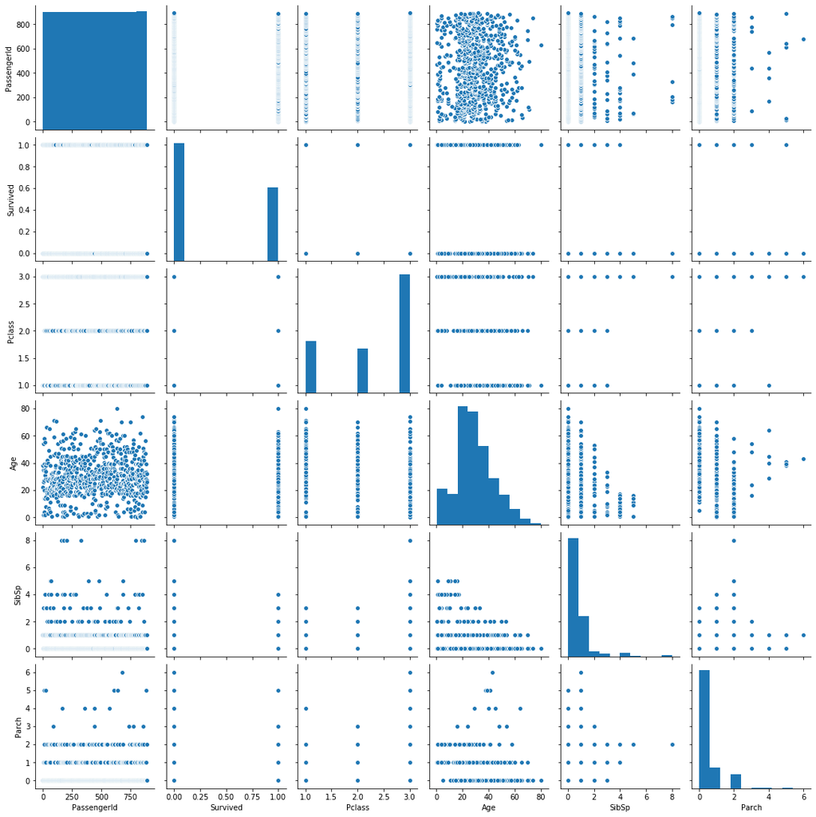

```python
info_cont = info.iloc[:,:-3]
sns.pairplot(info_cont)
```

```python
data=info.groupby(['Age', 'Survived'], axis=0)
data.size()
```

```
Age    Survived
0.42   1           1
0.67   1           1
0.75   1           2
0.83   1           2
0.92   1           1
                  ..
70.00  0           2
70.50  0           1
71.00  0           2
74.00  0           1
80.00  1           1
Length: 142, dtype: int64
```

From the two way table, we observe that children of Age<=4 and Age=80 had higher rate of survival.

```python
data=info.groupby(['Pclass', 'Survived'],axis=0)
data.size()
```

```
Pclass  Survived
1       0            80
        1           136
2       0            97
        1            87
3       0           372
        1           119
dtype: int64
```

From above two way table, we observe that maximum passengers from upper class or 1st class survived.

```python
data=info.groupby(['Sex', 'Survived'],axis=0)
data.size()
```

```
Sex     Survived
female  0            81
        1           233
male    0           468
        1           109
dtype: int64
```

From above two way table, we observe that Maximum number of Females survived.

```python
data=info.groupby(['Sex', 'Pclass'],axis=0)
data.size()
```

```
Sex     Pclass
female  1          94
        2          76
        3         144
male    1         122
        2         108
        3         347
dtype: int64
```

```python
data=info.groupby(['Embarked', 'Survived'],axis=0)
data.size()
```

```
Embarked  Survived
C         0            75
          1            93
Q         0            47
          1            30
S         0           427
          1           217
dtype: int64
```

```python
data=info.groupby(['SibSp', 'Survived'],axis=0)
data.size()
```

```
SibSp  Survived
0      0           398
       1           210
1      0            97
       1           112
2      0            15
       1            13
3      0            12
       1             4
4      0            15
       1             3
5      0             5
8      0             7
dtype: int64
```

Passengers with 0 siblings/spouses aboard the Titanic, survived the most.

```python
data=info.groupby(['Parch', 'Survived'],axis=0)
data.size()
```

```
Parch  Survived
0      0           445
       1           233
1      0            53
       1            65
2      0            40
       1            40
3      0             2
       1             3
4      0             4
5      0             4
       1             1
6      0             1
dtype: int64
```

Passengers with 0 parents/children aboard the Titanic, survived the most.

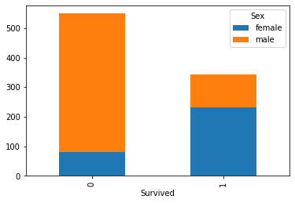

```python
pd.crosstab(info['Survived'],info['Sex']).plot(kind='bar', stacked=True)
```

From the above plot, we observe that more number of Female Passengers survived compared to Male passengers.

```
[]
```

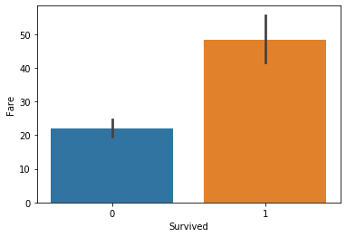

```python
sns.barplot(info['Survived'], info['Fare']).plot(kind='bar', stacked=True)
```

From the above plot, we observe that Maximum Passengers paying high Fare survived

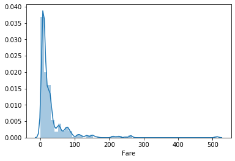

```python
sns.distplot(info['Fare'], kde=True)
```

```python
#MISSING VALUE TREATMENT:
```

```python
info
```

|  | PassengerId | Survived | Pclass | Name | Sex | Age | SibSp | Parch | Ticket | Fare | Cabin | Embarked |
| --- | --- | --- | --- | --- | --- | --- | --- | --- | --- | --- | --- | --- |
| 0 | 1 | 0 | 3 | Braund, Mr. Owen Harris | male | 22.0 | 1 | 0 | A/5 21171 | 7.2500 | NaN | S |
| 1 | 2 | 1 | 1 | Cumings, Mrs. John Bradley (Florence Briggs Th... | female | 38.0 | 1 | 0 | PC 17599 | 71.2833 | C85 | C |
| 2 | 3 | 1 | 3 | Heikkinen, Miss. Laina | female | 26.0 | 0 | 0 | STON/O2. 3101282 | 7.9250 | NaN | S |
| 3 | 4 | 1 | 1 | Futrelle, Mrs. Jacques Heath (Lily May Peel) | female | 35.0 | 1 | 0 | 113803 | 53.1000 | C123 | S |
| 4 | 5 | 0 | 3 | Allen, Mr. William Henry | male | 35.0 | 0 | 0 | 373450 | 8.0500 | NaN | S |
| ... | ... | ... | ... | ... | ... | ... | ... | ... | ... | ... | ... | ... |
| 886 | 887 | 0 | 2 | Montvila, Rev. Juozas | male | 27.0 | 0 | 0 | 211536 | 13.0000 | NaN | S |
| 887 | 888 | 1 | 1 | Graham, Miss. Margaret Edith | female | 19.0 | 0 | 0 | 112053 | 30.0000 | B42 | S |
| 888 | 889 | 0 | 3 | Johnston, Miss. Catherine Helen "Carrie" | female | NaN | 1 | 2 | W./C. 6607 | 23.4500 | NaN | S |
| 889 | 890 | 1 | 1 | Behr, Mr. Karl Howell | male | 26.0 | 0 | 0 | 111369 | 30.0000 | C148 | C |
| 890 | 891 | 0 | 3 | Dooley, Mr. Patrick | male | 32.0 | 0 | 0 | 370376 | 7.7500 | NaN | Q |

891 rows × 12 columns

```python
info.isnull()
```

|  | PassengerId | Survived | Pclass | Name | Sex | Age | SibSp | Parch | Ticket | Fare | Cabin | Embarked |
| --- | --- | --- | --- | --- | --- | --- | --- | --- | --- | --- | --- | --- |
| 0 | False | False | False | False | False | False | False | False | False | False | True | False |
| 1 | False | False | False | False | False | False | False | False | False | False | False | False |
| 2 | False | False | False | False | False | False | False | False | False | False | True | False |
| 3 | False | False | False | False | False | False | False | False | False | False | False | False |
| 4 | False | False | False | False | False | False | False | False | False | False | True | False |
| ... | ... | ... | ... | ... | ... | ... | ... | ... | ... | ... | ... | ... |
| 886 | False | False | False | False | False | False | False | False | False | False | True | False |
| 887 | False | False | False | False | False | False | False | False | False | False | False | False |
| 888 | False | False | False | False | False | True | False | False | False | False | True | False |
| 889 | False | False | False | False | False | False | False | False | False | False | False | False |
| 890 | False | False | False | False | False | False | False | False | False | False | True | False |

891 rows × 12 columns

```python
info.isnull().values.any()
```

```
True
```

```python
info.isnull().sum()
```

```
PassengerId      0
Survived         0
Pclass           0
Name             0
Sex              0
Age            177
SibSp            0
Parch            0
Ticket           0
Fare             0
Cabin          687
Embarked         2
dtype: int64
```

Age feature has 177 missing values. The Cabin feature has 687 missing values and Embarked has only 2 missing values.

```python
info.drop('Cabin', axis=1, inplace=True)
```

```python
info
```

|  | PassengerId | Survived | Pclass | Name | Sex | Age | SibSp | Parch | Ticket | Fare | Embarked |
| --- | --- | --- | --- | --- | --- | --- | --- | --- | --- | --- | --- |
| 0 | 1 | 0 | 3 | Braund, Mr. Owen Harris | male | 22.0 | 1 | 0 | A/5 21171 | 7.2500 | S |
| 1 | 2 | 1 | 1 | Cumings, Mrs. John Bradley (Florence Briggs Th... | female | 38.0 | 1 | 0 | PC 17599 | 71.2833 | C |
| 2 | 3 | 1 | 3 | Heikkinen, Miss. Laina | female | 26.0 | 0 | 0 | STON/O2. 3101282 | 7.9250 | S |
| 3 | 4 | 1 | 1 | Futrelle, Mrs. Jacques Heath (Lily May Peel) | female | 35.0 | 1 | 0 | 113803 | 53.1000 | S |
| 4 | 5 | 0 | 3 | Allen, Mr. William Henry | male | 35.0 | 0 | 0 | 373450 | 8.0500 | S |
| ... | ... | ... | ... | ... | ... | ... | ... | ... | ... | ... | ... |
| 886 | 887 | 0 | 2 | Montvila, Rev. Juozas | male | 27.0 | 0 | 0 | 211536 | 13.0000 | S |
| 887 | 888 | 1 | 1 | Graham, Miss. Margaret Edith | female | 19.0 | 0 | 0 | 112053 | 30.0000 | S |
| 888 | 889 | 0 | 3 | Johnston, Miss. Catherine Helen "Carrie" | female | NaN | 1 | 2 | W./C. 6607 | 23.4500 | S |
| 889 | 890 | 1 | 1 | Behr, Mr. Karl Howell | male | 26.0 | 0 | 0 | 111369 | 30.0000 | C |
| 890 | 891 | 0 | 3 | Dooley, Mr. Patrick | male | 32.0 | 0 | 0 | 370376 | 7.7500 | Q |

891 rows × 11 columns

```
array([[<matplotlib.axes._subplots.AxesSubplot object at 0x000002262AB7F688>]],
      dtype=object)
```

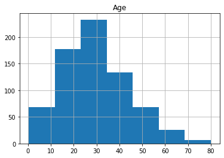

```python
info.hist(column=['Age'],bins=7)
```

```python
#Filling the missing values of Age with median:
```

```python
info['Age']=info['Age'].fillna(value=info['Age'].median())
info
```

|  | PassengerId | Survived | Pclass | Name | Sex | Age | SibSp | Parch | Ticket | Fare | Embarked |
| --- | --- | --- | --- | --- | --- | --- | --- | --- | --- | --- | --- |
| 0 | 1 | 0 | 3 | Braund, Mr. Owen Harris | male | 22.0 | 1 | 0 | A/5 21171 | 7.2500 | S |
| 1 | 2 | 1 | 1 | Cumings, Mrs. John Bradley (Florence Briggs Th... | female | 38.0 | 1 | 0 | PC 17599 | 71.2833 | C |
| 2 | 3 | 1 | 3 | Heikkinen, Miss. Laina | female | 26.0 | 0 | 0 | STON/O2. 3101282 | 7.9250 | S |
| 3 | 4 | 1 | 1 | Futrelle, Mrs. Jacques Heath (Lily May Peel) | female | 35.0 | 1 | 0 | 113803 | 53.1000 | S |
| 4 | 5 | 0 | 3 | Allen, Mr. William Henry | male | 35.0 | 0 | 0 | 373450 | 8.0500 | S |
| ... | ... | ... | ... | ... | ... | ... | ... | ... | ... | ... | ... |
| 886 | 887 | 0 | 2 | Montvila, Rev. Juozas | male | 27.0 | 0 | 0 | 211536 | 13.0000 | S |
| 887 | 888 | 1 | 1 | Graham, Miss. Margaret Edith | female | 19.0 | 0 | 0 | 112053 | 30.0000 | S |
| 888 | 889 | 0 | 3 | Johnston, Miss. Catherine Helen "Carrie" | female | 28.0 | 1 | 2 | W./C. 6607 | 23.4500 | S |
| 889 | 890 | 1 | 1 | Behr, Mr. Karl Howell | male | 26.0 | 0 | 0 | 111369 | 30.0000 | C |
| 890 | 891 | 0 | 3 | Dooley, Mr. Patrick | male | 32.0 | 0 | 0 | 370376 | 7.7500 | Q |

891 rows × 11 columns

```python
info.fillna(value='S',axis=1,inplace=True)
info
```

|  | PassengerId | Survived | Pclass | Name | Sex | Age | SibSp | Parch | Ticket | Fare | Embarked |
| --- | --- | --- | --- | --- | --- | --- | --- | --- | --- | --- | --- |
| 0 | 1 | 0 | 3 | Braund, Mr. Owen Harris | male | 22.0 | 1 | 0 | A/5 21171 | 7.2500 | S |
| 1 | 2 | 1 | 1 | Cumings, Mrs. John Bradley (Florence Briggs Th... | female | 38.0 | 1 | 0 | PC 17599 | 71.2833 | C |
| 2 | 3 | 1 | 3 | Heikkinen, Miss. Laina | female | 26.0 | 0 | 0 | STON/O2. 3101282 | 7.9250 | S |
| 3 | 4 | 1 | 1 | Futrelle, Mrs. Jacques Heath (Lily May Peel) | female | 35.0 | 1 | 0 | 113803 | 53.1000 | S |
| 4 | 5 | 0 | 3 | Allen, Mr. William Henry | male | 35.0 | 0 | 0 | 373450 | 8.0500 | S |
| ... | ... | ... | ... | ... | ... | ... | ... | ... | ... | ... | ... |
| 886 | 887 | 0 | 2 | Montvila, Rev. Juozas | male | 27.0 | 0 | 0 | 211536 | 13.0000 | S |
| 887 | 888 | 1 | 1 | Graham, Miss. Margaret Edith | female | 19.0 | 0 | 0 | 112053 | 30.0000 | S |
| 888 | 889 | 0 | 3 | Johnston, Miss. Catherine Helen "Carrie" | female | 28.0 | 1 | 2 | W./C. 6607 | 23.4500 | S |
| 889 | 890 | 1 | 1 | Behr, Mr. Karl Howell | male | 26.0 | 0 | 0 | 111369 | 30.0000 | C |
| 890 | 891 | 0 | 3 | Dooley, Mr. Patrick | male | 32.0 | 0 | 0 | 370376 | 7.7500 | Q |

891 rows × 11 columns

```python
info.isnull().sum()
```

```
PassengerId    0
Survived       0
Pclass         0
Name           0
Sex            0
Age            0
SibSp          0
Parch          0
Ticket         0
Fare           0
Embarked       0
dtype: int64
```

```python
#TREATING OUTLIERS:
```

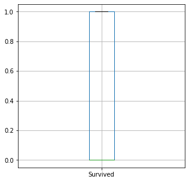

```python
info.boxplot(column=['Survived'], figsize=(5,5))
```

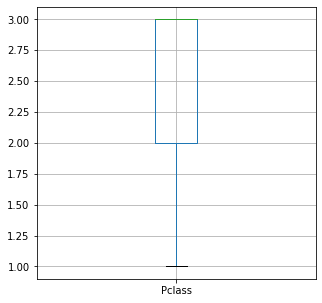

```python
info.boxplot(column=['Pclass'], figsize=(5,5))
```

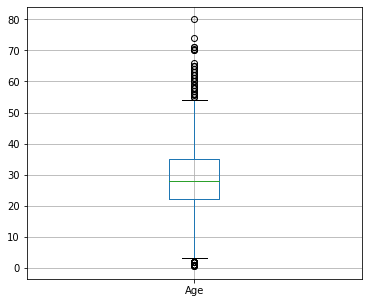

```python
info.boxplot(column=['Age'], figsize=(6,5))
```

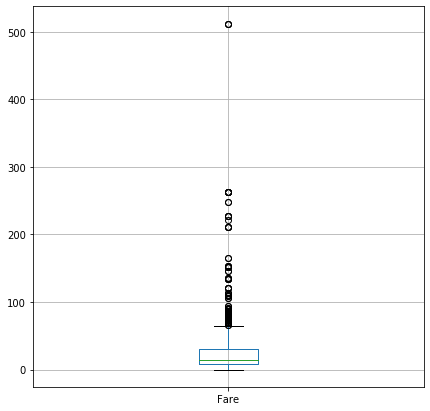

```python
 info.boxplot(column=['Fare'], figsize=(7,7))
```

Value beyond the range of -1.5 x IQR to +1.5 x IQR can be considered as Outlier. IQR=Q3-Q1

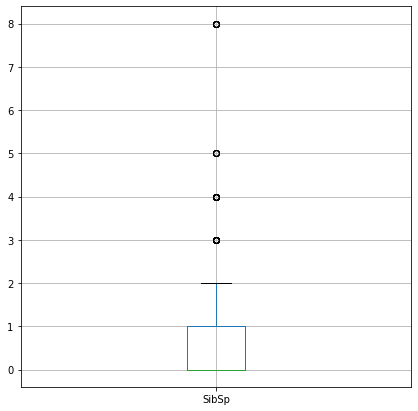

```python
info.boxplot(column=['SibSp'], figsize=(7,7))
```

```python
info['Age'].describe()
```

```
count    891.000000
mean      29.361582
std       13.019697
min        0.420000
25%       22.000000
50%       28.000000
75%       35.000000
max       80.000000
Name: Age, dtype: float64
```

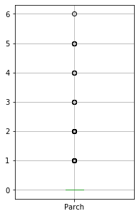

```python
info.boxplot(column=['Parch'], figsize=(3,5))
```

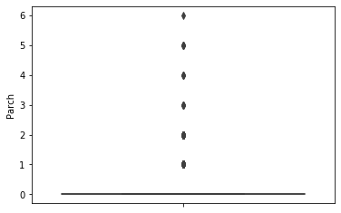

```python
sns.boxplot(y='Parch', data=info)
```

```python
IQR= info['Age'].quantile(0.75)-info['Age'].quantile(0.25)
IQR
```

```
13.0
```

```python
#Upper and lower limit:
```

```python
up_limit= info['Age'].quantile(0.75) + 1.5*IQR
low_limit= info['Age'].quantile(0.25) - 1.5*IQR
print(up_limit)
print(low_limit)
```

```
54.5
2.5
```

```python
values_outlier= info[(info['Age']>= up_limit) | (info['Age']<= low_limit)]
values_outlier
```

|  | PassengerId | Survived | Pclass | Name | Sex | Age | SibSp | Parch | Ticket | Fare | Embarked |
| --- | --- | --- | --- | --- | --- | --- | --- | --- | --- | --- | --- |
| 7 | 8 | 0 | 3 | Palsson, Master. Gosta Leonard | male | 2.00 | 3 | 1 | 349909 | 21.0750 | S |
| 11 | 12 | 1 | 1 | Bonnell, Miss. Elizabeth | female | 58.00 | 0 | 0 | 113783 | 26.5500 | S |
| 15 | 16 | 1 | 2 | Hewlett, Mrs. (Mary D Kingcome) | female | 55.00 | 0 | 0 | 248706 | 16.0000 | S |
| 16 | 17 | 0 | 3 | Rice, Master. Eugene | male | 2.00 | 4 | 1 | 382652 | 29.1250 | Q |
| 33 | 34 | 0 | 2 | Wheadon, Mr. Edward H | male | 66.00 | 0 | 0 | C.A. 24579 | 10.5000 | S |
| ... | ... | ... | ... | ... | ... | ... | ... | ... | ... | ... | ... |
| 827 | 828 | 1 | 2 | Mallet, Master. Andre | male | 1.00 | 0 | 2 | S.C./PARIS 2079 | 37.0042 | C |
| 829 | 830 | 1 | 1 | Stone, Mrs. George Nelson (Martha Evelyn) | female | 62.00 | 0 | 0 | 113572 | 80.0000 | S |
| 831 | 832 | 1 | 2 | Richards, Master. George Sibley | male | 0.83 | 1 | 1 | 29106 | 18.7500 | S |
| 851 | 852 | 0 | 3 | Svensson, Mr. Johan | male | 74.00 | 0 | 0 | 347060 | 7.7750 | S |
| 879 | 880 | 1 | 1 | Potter, Mrs. Thomas Jr (Lily Alexenia Wilson) | female | 56.00 | 0 | 1 | 11767 | 83.1583 | C |

66 rows × 11 columns

```python
values_outlier.reset_index(inplace=True)
for i in (values_outlier['index']):
    if info['Age'][i]>=up_limit:
        info['Age'][i]=info['Age'].quantile(0.95)
    else:
        info['Age'][i]=info['Age'].quantile(0.25)
```

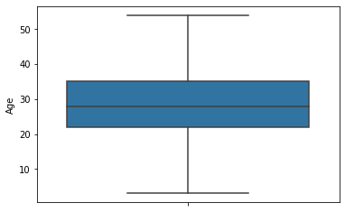

```python
sns.boxplot(y='Age',data=info)
```

```python
info['Fare'].describe()
```

```
count    891.000000
mean      32.204208
std       49.693429
min        0.000000
25%        7.910400
50%       14.454200
75%       31.000000
max      512.329200
Name: Fare, dtype: float64
```

```python
IQR= info['Fare'].quantile(0.75)-info['Fare'].quantile(0.25)
IQR
```

```
23.0896
```

```python
#Upper and lower limit:
```

```python
upperlimit= info['Fare'].quantile(0.75) + 1.5*IQR
lowerlimit= info['Fare'].quantile(0.25) - 1.5*IQR
print(upperlimit)
print(lowerlimit)
```

```
65.6344
-26.724
```

```python
values_outlier= info[(info['Fare']>= up_limit) | (info['Fare']<= low_limit)]
values_outlier
```

|  | PassengerId | Survived | Pclass | Name | Sex | Age | SibSp | Parch | Ticket | Fare | Embarked |
| --- | --- | --- | --- | --- | --- | --- | --- | --- | --- | --- | --- |
| 1 | 2 | 1 | 1 | Cumings, Mrs. John Bradley (Florence Briggs Th... | female | 38.0 | 1 | 0 | PC 17599 | 71.2833 | C |
| 27 | 28 | 0 | 1 | Fortune, Mr. Charles Alexander | male | 19.0 | 3 | 2 | 19950 | 263.0000 | S |
| 31 | 32 | 1 | 1 | Spencer, Mrs. William Augustus (Marie Eugenie) | female | 28.0 | 1 | 0 | PC 17569 | 146.5208 | C |
| 34 | 35 | 0 | 1 | Meyer, Mr. Edgar Joseph | male | 28.0 | 1 | 0 | PC 17604 | 82.1708 | C |
| 52 | 53 | 1 | 1 | Harper, Mrs. Henry Sleeper (Myna Haxtun) | female | 49.0 | 1 | 0 | PC 17572 | 76.7292 | C |
| ... | ... | ... | ... | ... | ... | ... | ... | ... | ... | ... | ... |
| 846 | 847 | 0 | 3 | Sage, Mr. Douglas Bullen | male | 28.0 | 8 | 2 | CA. 2343 | 69.5500 | S |
| 849 | 850 | 1 | 1 | Goldenberg, Mrs. Samuel L (Edwiga Grabowska) | female | 28.0 | 1 | 0 | 17453 | 89.1042 | C |
| 856 | 857 | 1 | 1 | Wick, Mrs. George Dennick (Mary Hitchcock) | female | 45.0 | 1 | 1 | 36928 | 164.8667 | S |
| 863 | 864 | 0 | 3 | Sage, Miss. Dorothy Edith "Dolly" | female | 28.0 | 8 | 2 | CA. 2343 | 69.5500 | S |
| 879 | 880 | 1 | 1 | Potter, Mrs. Thomas Jr (Lily Alexenia Wilson) | female | 54.0 | 0 | 1 | 11767 | 83.1583 | C |

156 rows × 11 columns

```python
values_outlier.reset_index(inplace=True)
value=info['Fare'].mean()
value
for i in (values_outlier['index']):
    info['Fare'][i]=value
```

```python
info
```

|  | PassengerId | Survived | Pclass | Name | Sex | Age | SibSp | Parch | Ticket | Fare | Embarked |
| --- | --- | --- | --- | --- | --- | --- | --- | --- | --- | --- | --- |
| 0 | 1 | 0 | 3 | Braund, Mr. Owen Harris | male | 22.0 | 1 | 0 | A/5 21171 | 7.250000 | S |
| 1 | 2 | 1 | 1 | Cumings, Mrs. John Bradley (Florence Briggs Th... | female | 38.0 | 1 | 0 | PC 17599 | 32.204208 | C |
| 2 | 3 | 1 | 3 | Heikkinen, Miss. Laina | female | 26.0 | 0 | 0 | STON/O2. 3101282 | 7.925000 | S |
| 3 | 4 | 1 | 1 | Futrelle, Mrs. Jacques Heath (Lily May Peel) | female | 35.0 | 1 | 0 | 113803 | 53.100000 | S |
| 4 | 5 | 0 | 3 | Allen, Mr. William Henry | male | 35.0 | 0 | 0 | 373450 | 8.050000 | S |
| ... | ... | ... | ... | ... | ... | ... | ... | ... | ... | ... | ... |
| 886 | 887 | 0 | 2 | Montvila, Rev. Juozas | male | 27.0 | 0 | 0 | 211536 | 13.000000 | S |
| 887 | 888 | 1 | 1 | Graham, Miss. Margaret Edith | female | 19.0 | 0 | 0 | 112053 | 30.000000 | S |
| 888 | 889 | 0 | 3 | Johnston, Miss. Catherine Helen "Carrie" | female | 28.0 | 1 | 2 | W./C. 6607 | 23.450000 | S |
| 889 | 890 | 1 | 1 | Behr, Mr. Karl Howell | male | 26.0 | 0 | 0 | 111369 | 30.000000 | C |
| 890 | 891 | 0 | 3 | Dooley, Mr. Patrick | male | 32.0 | 0 | 0 | 370376 | 7.750000 | Q |

891 rows × 11 columns

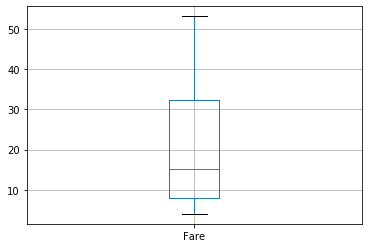

```python
info.boxplot(column=['Fare'])
```

```python
#FEATURE ENGINEERING: CREATING DUMMY VARIABLES:
```

```python
info.info()
```

```
<class 'pandas.core.frame.DataFrame'>
RangeIndex: 891 entries, 0 to 890
Data columns (total 11 columns):
 #   Column       Non-Null Count  Dtype
---  ------       --------------  -----
 0   PassengerId  891 non-null    int64
 1   Survived     891 non-null    int64
 2   Pclass       891 non-null    int64
 3   Name         891 non-null    object
 4   Sex          891 non-null    object
 5   Age          891 non-null    float64
 6   SibSp        891 non-null    int64
 7   Parch        891 non-null    int64
 8   Ticket       891 non-null    object
 9   Fare         891 non-null    float64
 10  Embarked     891 non-null    object
dtypes: float64(2), int64(5), object(4)
memory usage: 76.7+ KB
```

```python
obj= info.dtypes== np.object
obj
```

```
PassengerId    False
Survived       False
Pclass         False
Name            True
Sex             True
Age            False
SibSp          False
Parch          False
Ticket          True
Fare           False
Embarked        True
dtype: bool
```

```python
info.columns[obj]
```

```
Index(['Name', 'Sex', 'Ticket', 'Embarked'], dtype='object')
```

```python
info.drop(['Name', 'Ticket', 'PassengerId'], axis=1, inplace=True)
```

```python
info
```

|  | Survived | Pclass | Sex | Age | SibSp | Parch | Fare | Embarked |
| --- | --- | --- | --- | --- | --- | --- | --- | --- |
| 0 | 0 | 3 | male | 22.0 | 1 | 0 | 7.250000 | S |
| 1 | 1 | 1 | female | 38.0 | 1 | 0 | 32.204208 | C |
| 2 | 1 | 3 | female | 26.0 | 0 | 0 | 7.925000 | S |
| 3 | 1 | 1 | female | 35.0 | 1 | 0 | 53.100000 | S |
| 4 | 0 | 3 | male | 35.0 | 0 | 0 | 8.050000 | S |
| ... | ... | ... | ... | ... | ... | ... | ... | ... |
| 886 | 0 | 2 | male | 27.0 | 0 | 0 | 13.000000 | S |
| 887 | 1 | 1 | female | 19.0 | 0 | 0 | 30.000000 | S |
| 888 | 0 | 3 | female | 28.0 | 1 | 2 | 23.450000 | S |
| 889 | 1 | 1 | male | 26.0 | 0 | 0 | 30.000000 | C |
| 890 | 0 | 3 | male | 32.0 | 0 | 0 | 7.750000 | Q |

891 rows × 8 columns

```python
obj = info.dtypes == np.object
info.columns[obj]
```

```
Index(['Sex', 'Embarked'], dtype='object')
```

```python
info
```

|  | Survived | Pclass | Sex | Age | SibSp | Parch | Fare | Embarked |
| --- | --- | --- | --- | --- | --- | --- | --- | --- |
| 0 | 0 | 3 | male | 22.0 | 1 | 0 | 7.250000 | S |
| 1 | 1 | 1 | female | 38.0 | 1 | 0 | 32.204208 | C |
| 2 | 1 | 3 | female | 26.0 | 0 | 0 | 7.925000 | S |
| 3 | 1 | 1 | female | 35.0 | 1 | 0 | 53.100000 | S |
| 4 | 0 | 3 | male | 35.0 | 0 | 0 | 8.050000 | S |
| ... | ... | ... | ... | ... | ... | ... | ... | ... |
| 886 | 0 | 2 | male | 27.0 | 0 | 0 | 13.000000 | S |
| 887 | 1 | 1 | female | 19.0 | 0 | 0 | 30.000000 | S |
| 888 | 0 | 3 | female | 28.0 | 1 | 2 | 23.450000 | S |
| 889 | 1 | 1 | male | 26.0 | 0 | 0 | 30.000000 | C |
| 890 | 0 | 3 | male | 32.0 | 0 | 0 | 7.750000 | Q |

891 rows × 8 columns

```python
dummydf = pd.DataFrame()
for i in info.columns[obj]:
    dummy=pd.get_dummies(info[i], drop_first=True)
    dummydf = pd.concat([dummydf,dummy],axis=1)
print(dummydf)
```

```
     male  Q  S
0       1  0  1
1       0  0  0
2       0  0  1
3       0  0  1
4       1  0  1
..    ... .. ..
886     1  0  1
887     0  0  1
888     0  0  1
889     1  0  0
890     1  1  0

[891 rows x 3 columns]
```

```python
info1=pd.concat([info,dummydf], axis=1)
info1
```

|  | Survived | Pclass | Sex | Age | SibSp | Parch | Fare | Embarked | male | Q | S |
| --- | --- | --- | --- | --- | --- | --- | --- | --- | --- | --- | --- |
| 0 | 0 | 3 | male | 22.0 | 1 | 0 | 7.250000 | S | 1 | 0 | 1 |
| 1 | 1 | 1 | female | 38.0 | 1 | 0 | 32.204208 | C | 0 | 0 | 0 |
| 2 | 1 | 3 | female | 26.0 | 0 | 0 | 7.925000 | S | 0 | 0 | 1 |
| 3 | 1 | 1 | female | 35.0 | 1 | 0 | 53.100000 | S | 0 | 0 | 1 |
| 4 | 0 | 3 | male | 35.0 | 0 | 0 | 8.050000 | S | 1 | 0 | 1 |
| ... | ... | ... | ... | ... | ... | ... | ... | ... | ... | ... | ... |
| 886 | 0 | 2 | male | 27.0 | 0 | 0 | 13.000000 | S | 1 | 0 | 1 |
| 887 | 1 | 1 | female | 19.0 | 0 | 0 | 30.000000 | S | 0 | 0 | 1 |
| 888 | 0 | 3 | female | 28.0 | 1 | 2 | 23.450000 | S | 0 | 0 | 1 |
| 889 | 1 | 1 | male | 26.0 | 0 | 0 | 30.000000 | C | 1 | 0 | 0 |
| 890 | 0 | 3 | male | 32.0 | 0 | 0 | 7.750000 | Q | 1 | 1 | 0 |

891 rows × 11 columns

```python
info1.drop(['Sex', 'Embarked'], axis=1, inplace=True)
info1
```

|  | Survived | Pclass | Age | SibSp | Parch | Fare | male | Q | S |
| --- | --- | --- | --- | --- | --- | --- | --- | --- | --- |
| 0 | 0 | 3 | 22.0 | 1 | 0 | 7.250000 | 1 | 0 | 1 |
| 1 | 1 | 1 | 38.0 | 1 | 0 | 32.204208 | 0 | 0 | 0 |
| 2 | 1 | 3 | 26.0 | 0 | 0 | 7.925000 | 0 | 0 | 1 |
| 3 | 1 | 1 | 35.0 | 1 | 0 | 53.100000 | 0 | 0 | 1 |
| 4 | 0 | 3 | 35.0 | 0 | 0 | 8.050000 | 1 | 0 | 1 |
| ... | ... | ... | ... | ... | ... | ... | ... | ... | ... |
| 886 | 0 | 2 | 27.0 | 0 | 0 | 13.000000 | 1 | 0 | 1 |
| 887 | 1 | 1 | 19.0 | 0 | 0 | 30.000000 | 0 | 0 | 1 |
| 888 | 0 | 3 | 28.0 | 1 | 2 | 23.450000 | 0 | 0 | 1 |
| 889 | 1 | 1 | 26.0 | 0 | 0 | 30.000000 | 1 | 0 | 0 |
| 890 | 0 | 3 | 32.0 | 0 | 0 | 7.750000 | 1 | 1 | 0 |

891 rows × 9 columns

```python
info2 = pd.get_dummies(info, drop_first=True)
```

```python
info2.drop(['SibSp', 'Parch'], axis=1, inplace=True)
```

```python
info2
```

|  | Survived | Pclass | Age | Fare | Sex_male | Embarked_Q | Embarked_S |
| --- | --- | --- | --- | --- | --- | --- | --- |
| 0 | 0 | 3 | 22.0 | 7.250000 | 1 | 0 | 1 |
| 1 | 1 | 1 | 38.0 | 32.204208 | 0 | 0 | 0 |
| 2 | 1 | 3 | 26.0 | 7.925000 | 0 | 0 | 1 |
| 3 | 1 | 1 | 35.0 | 53.100000 | 0 | 0 | 1 |
| 4 | 0 | 3 | 35.0 | 8.050000 | 1 | 0 | 1 |
| ... | ... | ... | ... | ... | ... | ... | ... |
| 886 | 0 | 2 | 27.0 | 13.000000 | 1 | 0 | 1 |
| 887 | 1 | 1 | 19.0 | 30.000000 | 0 | 0 | 1 |
| 888 | 0 | 3 | 28.0 | 23.450000 | 0 | 0 | 1 |
| 889 | 1 | 1 | 26.0 | 30.000000 | 1 | 0 | 0 |
| 890 | 0 | 3 | 32.0 | 7.750000 | 1 | 1 | 0 |

891 rows × 7 columns

```python
#Part 2:
```

```python
X = info2.iloc[:,:-1].values
X.shape
```

```
(891, 6)
```

```python
y = info2.iloc[:,-1].values
y.shape
```

```
(891,)
```

```python
from sklearn.model_selection import train_test_split
X_train, X_test, y_train, y_test = train_test_split(X, y, test_size=0.25, random_state = 0)
```

```python
X_train.shape
```

```
(668, 6)
```

```python
X_test.shape
```

```
(223, 6)
```

```python
y_train.shape
```

```
(668,)
```

```python
y_test.shape
```

```
(223,)
```

```python
from sklearn.linear_model import LogisticRegression
lr = LogisticRegression()
lr.fit(X_train, y_train)
```

```
LogisticRegression(C=1.0, class_weight=None, dual=False, fit_intercept=True,
                   intercept_scaling=1, l1_ratio=None, max_iter=100,
                   multi_class='auto', n_jobs=None, penalty='l2',
                   random_state=None, solver='lbfgs', tol=0.0001, verbose=0,
                   warm_start=False)
```

```python
y_pred = lr.predict(X_test)
```

```python
y_test
```

```
array([0, 1, 0, 0, 0, 1, 1, 1, 0, 0, 1, 1, 0, 1, 0, 1, 1, 1, 1, 0, 1, 1,
       0, 1, 1, 0, 1, 1, 1, 1, 0, 1, 1, 1, 1, 0, 1, 1, 1, 1, 0, 0, 1, 1,
       1, 1, 1, 0, 1, 1, 1, 0, 1, 1, 0, 1, 1, 1, 1, 0, 0, 1, 0, 0, 1, 0,
       1, 1, 1, 1, 1, 1, 0, 1, 1, 1, 1, 0, 1, 0, 0, 1, 1, 1, 1, 1, 0, 1,
       1, 0, 1, 1, 1, 0, 1, 0, 1, 1, 1, 0, 1, 1, 1, 1, 1, 1, 1, 1, 1, 0,
       1, 1, 1, 1, 1, 1, 1, 0, 1, 1, 1, 0, 1, 1, 1, 0, 0, 1, 1, 1, 0, 1,
       1, 1, 1, 1, 0, 1, 1, 1, 1, 0, 1, 0, 1, 1, 1, 1, 0, 1, 1, 1, 1, 1,
       0, 1, 0, 1, 0, 0, 1, 0, 0, 1, 0, 1, 1, 1, 1, 1, 1, 0, 1, 1, 0, 1,
       0, 1, 1, 0, 1, 0, 0, 1, 1, 1, 0, 1, 1, 1, 1, 1, 0, 0, 0, 0, 1, 1,
       1, 1, 1, 0, 1, 0, 1, 0, 1, 1, 0, 1, 1, 0, 1, 0, 1, 1, 0, 1, 1, 0,
       1, 0, 1], dtype=uint8)
```

```python
y_pred
```

```
array([1, 1, 0, 1, 1, 1, 1, 1, 1, 1, 1, 1, 0, 1, 1, 1, 1, 1, 1, 1, 1, 1,
       0, 1, 1, 1, 1, 1, 1, 1, 1, 1, 1, 1, 1, 1, 1, 1, 1, 1, 1, 1, 1, 1,
       1, 1, 1, 1, 1, 1, 1, 1, 1, 1, 1, 1, 1, 1, 1, 0, 1, 1, 1, 1, 1, 0,
       1, 1, 1, 1, 1, 1, 1, 1, 1, 1, 1, 1, 1, 1, 0, 1, 1, 1, 1, 1, 1, 1,
       1, 1, 1, 1, 1, 1, 1, 1, 1, 1, 1, 1, 1, 1, 1, 1, 1, 1, 1, 1, 1, 0,
       1, 1, 1, 1, 1, 1, 1, 1, 1, 1, 1, 0, 1, 1, 1, 1, 1, 1, 1, 1, 0, 1,
       1, 1, 1, 1, 0, 1, 1, 1, 1, 0, 1, 0, 1, 1, 1, 1, 1, 1, 1, 1, 1, 1,
       1, 1, 1, 1, 0, 1, 1, 1, 1, 1, 1, 1, 1, 1, 1, 1, 1, 1, 1, 1, 1, 1,
       1, 1, 1, 1, 1, 1, 1, 1, 1, 1, 0, 1, 1, 1, 1, 1, 1, 0, 0, 1, 1, 1,
       1, 1, 1, 1, 1, 1, 1, 1, 1, 1, 0, 1, 1, 1, 1, 1, 1, 1, 1, 1, 1, 1,
       1, 1, 1], dtype=uint8)
```

```python
#Model Evaluation using Confusion Matrix:
```

```python
from sklearn.metrics import confusion_matrix
confusion = confusion_matrix(y_test, y_pred)
print(confusion)
```

```
[[ 17  52]
 [  0 154]]
```

```python
TN = confusion [0,0]
FP = confusion [0,1]
FN = confusion [1,0]
TP = confusion [1,1]
```

```python
print(confusion)
print ("TN: ", TN)
print ("FP: ", FP)
print ("FN: ", FN)
print ("TP: ", TP)
```

```
[[ 17  52]
 [  0 154]]
TN:  17
FP:  52
FN:  0
TP:  154
```

```python
from sklearn import metrics
accuracy = metrics.accuracy_score(y_test, y_pred)
accuracy1 = (TN+TP)/(TN+TP+FN+FP)
print ("Accuracy from metrics: ", accuracy)
print ("Accuracy Calculated: ", accuracy1)
```

```
Accuracy from metrics:  0.7668161434977578
Accuracy Calculated:  0.7668161434977578
```

```python
#Classification Error:
```

```python
print ((FP+FN)/float(TP+TN+FP+FN))
print (round(1-metrics.accuracy_score(y_test, y_pred),4))
```

```
0.23318385650224216
0.2332
```

```python
#Sensitivity:
```

```python
print ("RECALL:", metrics.recall_score(y_test,y_pred))
print("CALCULATED RECALL: ", (TP)/(TP+FN))
```

```
RECALL: 1.0
CALCULATED RECALL:  1.0
```

```python
#Specificity:
```

```python
print ("SPECIFICITY/TRUE NEGATIVE RATE:", (TN)/(TN+FP))
```

```
SPECIFICITY/TRUE NEGATIVE RATE: 0.2463768115942029
```

```python
#False Positive Rate:
```

```python
print("FALSE POSITIVE RATE: ",(FN)/(FN+TP))
```

[output not shown]

```python
print("FALSE NEGATIVE RATE: ",(FP)/(TN+FP))
```

[output not shown]

```python
#Precision:
```

```python
print ("Precision: ", round(metrics.precision_score(y_test,y_pred),2))
print ("PRECISION CALCULATED: ", round(TP/float(TP+FP),2))
```

```
Precision:  0.75
PRECISION CALCULATED:  0.75
```

```python
from sklearn.metrics import accuracy_score,f1_score,precision_score,recall_score,roc_auc_score
accuracy = accuracy_score(y_test, y_pred)
recall = recall_score(y_test, y_pred)
precision = precision_score(y_test, y_pred)
f1 = f1_score(y_test, y_pred)
roc_auc = roc_auc_score(y_test, y_pred)

print('Accuracy is  :' ,round(accuracy,2)*100)
print('F1 score is :' ,round(f1,2)*100)
print('Precision is  :',round(precision,2)*100)
print('Recall is  :',round(recall,4)*100)
print('Roc Auc is  :',round(roc_auc,2)*100)
```

```
Accuracy is  : 77.0
F1 score is : 86.0
Precision is  : 75.0
Recall is  : 100.0
Roc Auc is  : 62.0
```

```python
from sklearn.metrics import classification_report
print(classification_report(y_test, y_pred))
```

```
              precision    recall  f1-score   support

           0       1.00      0.25      0.40        69
           1       0.75      1.00      0.86       154

    accuracy                           0.77       223
   macro avg       0.87      0.62      0.63       223
weighted avg       0.83      0.77      0.71       223
```

```python
summary=pd.DataFrame([accuracy, f1, precision, recall,roc_auc], index=['Accuracy', 'F1', 'Precision', 'Recall', 'AUC'], columns=['Values'])
summary
```

|  | Values |
| --- | --- |
| Accuracy | 0.766816 |
| F1 | 0.855556 |
| Precision | 0.747573 |
| Recall | 1.000000 |
| AUC | 0.623188 |

```python
from sklearn.neighbors import KNeighborsClassifier
knn = KNeighborsClassifier()
knn.fit(X_train,y_train)
```

```
KNeighborsClassifier(algorithm='auto', leaf_size=30, metric='minkowski',
                     metric_params=None, n_jobs=None, n_neighbors=5, p=2,
                     weights='uniform')
```

```python
y_pred = knn.predict(X_test)
```

```python
from sklearn.metrics import confusion_matrix, accuracy_score, classification_report
confusion_matrix(y_test, y_pred)
```

```
array([[ 30,  39],
       [ 12, 142]], dtype=int64)
```

```python
accuracy_score(y_test, y_pred)
```

```
0.7713004484304933
```

```python
error = []
accuracy = []

for i in range(1,40,2):
    knn = KNeighborsClassifier(n_neighbors=i)
    knn.fit(X_train, y_train)
    pred_i = knn.predict(X_test)
    error.append(np.mean(pred_i != y_test))
    accuracy.append(accuracy_score(y_test, pred_i))
```

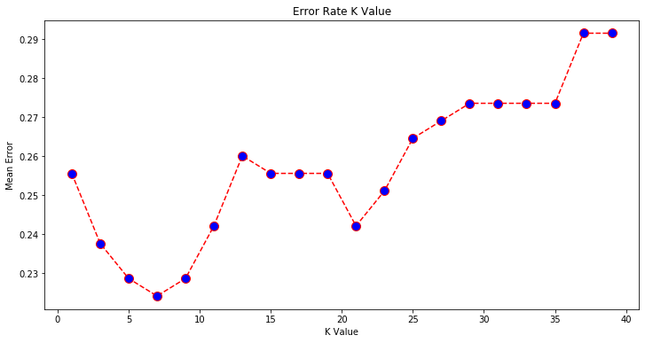

```python
plt.figure(figsize=(12, 6))
plt.plot(range(1,40,2), error, color='red', linestyle='dashed', marker='o',
         markerfacecolor='blue', markersize=10)
plt.title('Error Rate K Value')
plt.xlabel('K Value')
plt.ylabel('Mean Error')
```

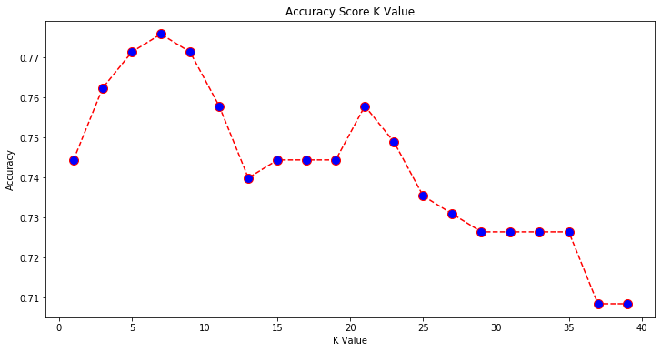

```python
plt.figure(figsize=(12, 6))
plt.plot(range(1,40,2), accuracy, color='red', linestyle='dashed', marker='o',
         markerfacecolor='blue', markersize=10)
plt.title('Accuracy Score K Value')
plt.xlabel('K Value')
plt.ylabel('Accuracy')
```

```python
from sklearn.neighbors import KNeighborsClassifier
knn = KNeighborsClassifier(n_neighbors=7)
knn.fit(X_train,y_train)
```

```
KNeighborsClassifier(algorithm='auto', leaf_size=30, metric='minkowski',
                     metric_params=None, n_jobs=None, n_neighbors=7, p=2,
                     weights='uniform')
```

```python
y_pred1 = knn.predict(X_test)
```

```python
confusion_matrix(y_test, y_pred1)
```

```
array([[ 28,  41],
       [  9, 145]], dtype=int64)
```

```python
accuracy_score(y_test, y_pred1)
```

```
0.7757847533632287
```

```python
from sklearn.tree import DecisionTreeClassifier
```

```python
clf = DecisionTreeClassifier()
clf = clf.fit(X_train,y_train)
y_pred = clf.predict(X_test)
y_pred
```

```
array([1, 1, 0, 0, 0, 1, 0, 0, 0, 0, 1, 1, 0, 1, 0, 0, 1, 1, 1, 1, 1, 1,
       0, 0, 1, 0, 0, 1, 1, 1, 1, 1, 1, 1, 1, 1, 0, 1, 1, 1, 0, 0, 1, 1,
       1, 1, 1, 1, 1, 0, 1, 1, 1, 1, 0, 1, 1, 1, 1, 0, 0, 1, 0, 1, 1, 0,
       1, 1, 1, 0, 1, 1, 1, 1, 1, 1, 0, 0, 1, 1, 0, 1, 1, 1, 1, 1, 0, 1,
       1, 0, 1, 1, 1, 1, 1, 0, 1, 1, 1, 0, 1, 1, 1, 1, 1, 1, 1, 1, 1, 0,
       1, 1, 1, 1, 0, 1, 1, 1, 1, 1, 1, 0, 1, 1, 1, 0, 0, 1, 1, 1, 0, 1,
       1, 1, 1, 1, 0, 1, 1, 1, 1, 0, 1, 0, 1, 1, 1, 1, 1, 1, 1, 1, 1, 1,
       1, 1, 1, 1, 0, 0, 1, 0, 0, 1, 0, 1, 1, 1, 1, 1, 1, 0, 1, 1, 0, 1,
       0, 1, 1, 0, 1, 1, 0, 1, 0, 1, 0, 1, 1, 1, 1, 1, 0, 0, 0, 1, 1, 1,
       1, 1, 1, 0, 1, 0, 1, 1, 1, 1, 0, 1, 1, 0, 1, 0, 1, 1, 1, 0, 1, 0,
       1, 1, 1], dtype=uint8)
```

```python
 from sklearn import metrics
```

```python
print("Accuracy:",round(metrics.accuracy_score(y_test, y_pred)*100,2),
"%")
```

```
Accuracy: 86.1 %
```

```python
 from sklearn.metrics import confusion_matrix
```

```python
cm=confusion_matrix(y_test,y_pred)
cm
```

```
array([[ 50,  19],
       [ 12, 142]], dtype=int64)
```

```python
print(classification_report(y_test,y_pred))
```

```
              precision    recall  f1-score   support

           0       0.81      0.72      0.76        69
           1       0.88      0.92      0.90       154

    accuracy                           0.86       223
   macro avg       0.84      0.82      0.83       223
weighted avg       0.86      0.86      0.86       223
```

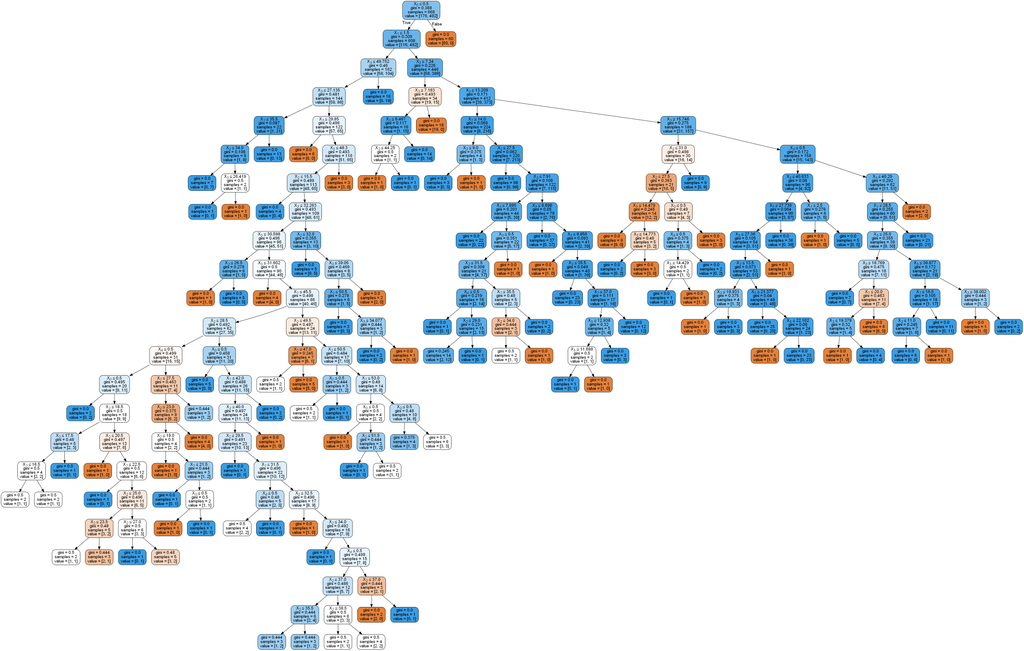

```python
from sklearn.externals.six import StringIO
from IPython.display import Image
from sklearn.tree import export_graphviz
import pydotplus
dot_data = StringIO()
export_graphviz(clf, out_file=dot_data,
 filled=True, rounded=True,special_characters=True)
graph = pydotplus.graph_from_dot_data(dot_data.getvalue())
Image(graph.create_png(), width=12000, height=12000)
```

```python
 from sklearn.ensemble import RandomForestClassifier
clf = RandomForestClassifier(n_estimators = 100)
clf.fit(X_train, y_train)
```

```
RandomForestClassifier(bootstrap=True, ccp_alpha=0.0, class_weight=None,
                       criterion='gini', max_depth=None, max_features='auto',
                       max_leaf_nodes=None, max_samples=None,
                       min_impurity_decrease=0.0, min_impurity_split=None,
                       min_samples_leaf=1, min_samples_split=2,
                       min_weight_fraction_leaf=0.0, n_estimators=100,
                       n_jobs=None, oob_score=False, random_state=None,
                       verbose=0, warm_start=False)
```

```python
y_pred = clf.predict(X_test)
y_pred
```

```
array([1, 1, 0, 0, 1, 1, 1, 1, 0, 0, 1, 1, 0, 1, 0, 1, 1, 1, 1, 1, 1, 1,
       0, 0, 1, 1, 1, 1, 1, 1, 1, 1, 1, 1, 1, 1, 1, 1, 1, 1, 1, 0, 1, 1,
       1, 1, 1, 1, 1, 0, 1, 1, 1, 1, 1, 1, 1, 1, 1, 0, 0, 1, 0, 1, 1, 0,
       1, 1, 1, 0, 1, 1, 1, 1, 1, 1, 1, 0, 0, 1, 0, 1, 1, 1, 1, 1, 0, 1,
       1, 1, 1, 1, 1, 1, 1, 0, 1, 1, 1, 1, 1, 1, 1, 1, 1, 1, 1, 1, 1, 0,
       1, 1, 1, 1, 0, 1, 1, 1, 1, 1, 1, 0, 1, 1, 1, 1, 0, 1, 1, 1, 0, 1,
       1, 1, 1, 1, 0, 1, 1, 1, 1, 0, 1, 0, 1, 1, 1, 1, 0, 1, 1, 1, 1, 1,
       1, 1, 1, 1, 0, 0, 1, 0, 0, 1, 0, 1, 1, 1, 1, 1, 1, 0, 1, 1, 0, 1,
       1, 1, 1, 1, 1, 1, 1, 1, 0, 1, 0, 1, 1, 1, 1, 1, 0, 0, 0, 1, 1, 1,
       0, 1, 1, 0, 1, 1, 1, 1, 1, 1, 0, 1, 1, 1, 1, 0, 1, 1, 1, 1, 1, 0,
       1, 1, 0], dtype=uint8)
```

```python
y_test
```

```
array([0, 1, 0, 0, 0, 1, 1, 1, 0, 0, 1, 1, 0, 1, 0, 1, 1, 1, 1, 0, 1, 1,
       0, 1, 1, 0, 1, 1, 1, 1, 0, 1, 1, 1, 1, 0, 1, 1, 1, 1, 0, 0, 1, 1,
       1, 1, 1, 0, 1, 1, 1, 0, 1, 1, 0, 1, 1, 1, 1, 0, 0, 1, 0, 0, 1, 0,
       1, 1, 1, 1, 1, 1, 0, 1, 1, 1, 1, 0, 1, 0, 0, 1, 1, 1, 1, 1, 0, 1,
       1, 0, 1, 1, 1, 0, 1, 0, 1, 1, 1, 0, 1, 1, 1, 1, 1, 1, 1, 1, 1, 0,
       1, 1, 1, 1, 1, 1, 1, 0, 1, 1, 1, 0, 1, 1, 1, 0, 0, 1, 1, 1, 0, 1,
       1, 1, 1, 1, 0, 1, 1, 1, 1, 0, 1, 0, 1, 1, 1, 1, 0, 1, 1, 1, 1, 1,
       0, 1, 0, 1, 0, 0, 1, 0, 0, 1, 0, 1, 1, 1, 1, 1, 1, 0, 1, 1, 0, 1,
       0, 1, 1, 0, 1, 0, 0, 1, 1, 1, 0, 1, 1, 1, 1, 1, 0, 0, 0, 0, 1, 1,
       1, 1, 1, 0, 1, 0, 1, 0, 1, 1, 0, 1, 1, 0, 1, 0, 1, 1, 0, 1, 1, 0,
       1, 0, 1], dtype=uint8)
```

```python
y_pred
```

```
array([1, 1, 0, 0, 1, 1, 1, 1, 0, 0, 1, 1, 0, 1, 0, 1, 1, 1, 1, 1, 1, 1,
       0, 0, 1, 1, 1, 1, 1, 1, 1, 1, 1, 1, 1, 1, 1, 1, 1, 1, 1, 0, 1, 1,
       1, 1, 1, 1, 1, 0, 1, 1, 1, 1, 1, 1, 1, 1, 1, 0, 0, 1, 0, 1, 1, 0,
       1, 1, 1, 0, 1, 1, 1, 1, 1, 1, 1, 0, 0, 1, 0, 1, 1, 1, 1, 1, 0, 1,
       1, 1, 1, 1, 1, 1, 1, 0, 1, 1, 1, 1, 1, 1, 1, 1, 1, 1, 1, 1, 1, 0,
       1, 1, 1, 1, 0, 1, 1, 1, 1, 1, 1, 0, 1, 1, 1, 1, 0, 1, 1, 1, 0, 1,
       1, 1, 1, 1, 0, 1, 1, 1, 1, 0, 1, 0, 1, 1, 1, 1, 0, 1, 1, 1, 1, 1,
       1, 1, 1, 1, 0, 0, 1, 0, 0, 1, 0, 1, 1, 1, 1, 1, 1, 0, 1, 1, 0, 1,
       1, 1, 1, 1, 1, 1, 1, 1, 0, 1, 0, 1, 1, 1, 1, 1, 0, 0, 0, 1, 1, 1,
       0, 1, 1, 0, 1, 1, 1, 1, 1, 1, 0, 1, 1, 1, 1, 0, 1, 1, 1, 1, 1, 0,
       1, 1, 0], dtype=uint8)
```

```python
from sklearn import metrics
from sklearn.metrics import confusion_matrix
```

```python
cm = confusion_matrix(y_test, y_pred)
cm
```

```
array([[ 39,  30],
       [  8, 146]], dtype=int64)
```

```python
 metrics.accuracy_score(y_test, y_pred)
```

```
0.8295964125560538
```

```python
#THE BEST MODEL BASED ON THE ACCURACY RESULT IS: DECISION TREE
```